# Comparative Effectiveness of Oral Monotherapy Versus Dual Therapy on HbA1c Levels Among Adults With Type 2 Diabetes and Hyperglycemia

Using 2017–2020 NHANES Data

Author

Lily Zhang

Modified

2026-04-12

## Initial Setup

```r
knitr::opts_chunk$set(comment = NA)

library(nhanesA)
library(tidyverse)
library(dplyr)
library(janitor)
library(conflicted)
library(naniar)
library(mice)
library(tableone)
library(broom)
library(kableExtra)
library(Matching)
library(cobalt)
library(lme4)
library(twang)
library(survey)
library(rbounds)

library(easystats)
library(tidyverse)
conflicts_prefer(dplyr::select, dplyr::filter)
theme_set(theme_bw())

options(dplyr.summarise.inform = FALSE)
knitr::opts_chunk$set(comment=NA)
```

# 1 Background

## 1.1 Data Source

The data used in this study come from the National Health and Nutrition Examination Survey (NHANES) 2017 - March 2020 Pre-pandemic Data from the Centers for Disease Control and Prevention. The data are described in detail and accessed [here](https://wwwn.cdc.gov/nchs/nhanes/continuousnhanes/default.aspx?Cycle=2017-2020).

## 1.2 Rational

Type 2 diabetes mellitus (T2DM) is one of the most prevalent chronic diseases in the United States. In addition, a large prediabetic population further highlights the growing public health burden of this disease. Effective glycemic control is essential for reducing complications, making pharmacologic therapy a cornerstone of diabetes management, with metformin as first-line treatment and sulfonylureas commonly used as an alternative or add-on therapy. Hemoglobin A1c (HbA1c), which reflects average blood glucose levels over the past two to three months, is widely used for both diagnosis and monitoring and serves as a key indicator of long-term glycemic control.

## 1.3 Subjects

This study will use data from the NHANES 2017 - March 2020 pre-pandemic cycle, a nationally representative, cross-sectional survey of the U.S. population. Participants included in this study were adults aged over 21 years who had been previously told by a healthcare professional that they had diabetes or prediabetes and who completed both the interview and examination components of NHANES, and who reported using either metformin or a sulfonylurea within the past 365 days. A total of 738 subjects with complete data on both the exposure (medication: monotherapy vs dual therapy) and the outcome (HbA1c level) were included in this study. Among them, 177 subjects were receiving dual therapy.

## 1.4 Objective

The primary objective of this study is to evaluate the comparative effectiveness of oral monotherapy (metformin or sulfonylurea) versus dual therapy (metformin plus sulfonylurea) in reducing HbA1c levels among adults with type 2 diabetes in an observational setting. Specifically, this study aims to quantify the difference in HbA1c levels between patients receiving monotherapy and those receiving dual therapy, while accounting for potential confounding factors through appropriate adjustment methods.

## 1.5 Research Question

Among NHANES adults aged 21 years or older with diabetes or hyperglycemia, what is the association between oral monotherapy (metformin or sulfonylurea) and dual therapy (metformin plus sulfonylurea) with glycemic control after adjusting for age, sex, race/ethnicity, BMI, insurance status, and healthcare utilization over the past year?

# 2 Data Ingest

## 2.1 Loading the Raw Data

To begin with, all data needed for this study are loaded from the 2017-March 2020 NHANES data into a tibble in R.

```r
demo_raw <- nhanes('P_DEMO') |> tibble() |>
  janitor::clean_names()

ghb_raw <- nhanes('P_GHB') |> tibble() |>
  janitor::clean_names()

diq_raw <- nhanes('P_DIQ') |> tibble() |>
  janitor::clean_names()

rxq_raw <- nhanes('P_RXQ_RX') |> tibble() |>
  janitor::clean_names()

sbp_raw <- nhanes('P_BPXO') |> tibble() |>
  janitor::clean_names()

bmi_raw <- nhanes('P_BMX') |> tibble() |>
  janitor::clean_names()

alq_raw <- nhanes('P_ALQ') |> tibble() |>
  janitor::clean_names()

ins_raw <- nhanes('P_HIQ') |> tibble() |>
  janitor::clean_names()

hosp_raw <- nhanes('P_HUQ') |> tibble() |>
  janitor::clean_names()
```

## 2.2 Contents of the Raw Tibbles

I now have nine tibbles that will provide complete data on all subjects and variables once joined.

- `demo_raw` contains data on 29 variables for 15560 subjects.

```r
dim(demo_raw)
```

```
[1] 15560    29
```

- `ghb_raw` contains data on 2 variables for 10409 subjects.

```r
dim(ghb_raw)
```

```
[1] 10409     2
```

- `diq_raw` contains data on 28 variables for 14986 subjects.

```r
dim(diq_raw)
```

```
[1] 14986    28
```

- `rxq_raw` contains data on 13 variables for 32962 subjects.

```r
dim(rxq_raw)
```

```
[1] 32962    13
```

- `sbp_raw` contains data on 12 variables for 11656 subjects.

```r
dim(sbp_raw)
```

```
[1] 11656    12
```

- `bmi_raw` contains data on 22 variables for 14300 subjects.

```r
dim(bmi_raw)
```

```
[1] 14300    22
```

- `alq_raw` contains data on 10 variables for 8965 subjects.

```r
dim(alq_raw)
```

```
[1] 8965   10
```

- `ins_raw` contains data on 14 variables for 15560 subjects.

```r
dim(ins_raw)
```

```
[1] 15560    14
```

- `hosp_raw` contains data on 7 variables for 15560 subjects.

```r
dim(hosp_raw)
```

```
[1] 15560     7
```

## 2.3 Joining the tibbles

First, all tibbles, except for `rxq_raw`, are joined together to form a single tibble named `proj_raw`.

```r
proj_raw <- demo_raw |>
  left_join(ghb_raw, by = "seqn") |>
  left_join(diq_raw, by = "seqn") |>
  left_join(sbp_raw, by = "seqn") |>
  left_join(bmi_raw, by = "seqn") |>
  left_join(alq_raw, by = "seqn") |>
  left_join(ins_raw, by = "seqn") |>
  left_join(hosp_raw, by = "seqn")

dim(proj_raw)
```

```
[1] 15560   117
```

## 2.4 Checking the Joined Tibble

First, I need to check to make sure that the number of unique subject identification codes seqn matghes the number of rows.

```r
identical(n_distinct(proj_raw$seqn), proj_raw |> nrow())
```

```
[1] TRUE
```

Second, I also need to check that no new variables are added to the tibble.

```r
identical(sort(names(proj_raw)),
  sort(unique(c(names(demo_raw), names(ghb_raw), names(diq_raw),
                names(sbp_raw), names(bmi_raw), names(alq_raw),
                names(ins_raw), names(hosp_raw)))))
```

```
[1] TRUE
```

The joined tibble can be used for further steps.

## 2.5 Selecting variables

Here, I reduce the `proj_raw` data to the variables I will use in this study. I also convert the subject identification code `seqn` from numeric to character.

```r
dat <- proj_raw |>
  mutate(seqn = as.character(seqn)) |>
  select(seqn, ridageyr, ridstatr, riagendr, ridreth3,
         diq010, # have ever diabetes
         diq160, # Ever told you have prediabetes
         bpxosy1, bpxosy2, bpxosy3, #sbp
         bmxbmi,
         lbxgh, # HbA1c
         alq121, # Past 12 mo how often drink alcoholic bev
         huq051, #times receive healthcare over past year
         hiq011, # No for uninsured
         hiq032a, # 1 Covered by private insurance
         hiq032b, # 2 Covered by Medicare
         hiq032d, # - 4 Covered by Medicaid
         )
```

# 3 Cleaning the Data

## 3.1 Filting for Aligiable Patients

The variable `ridageyr` will be filtered to include only subjects over 21 years of age. And because this data set includes variables from the Questionnaire data group, the variable `ridstatr` must be restricted to participants who were both interviewed and MEC examined for the analysis to be valid.

```r
dat_clean <- dat |>
  filter(ridageyr >= 21,
         ridstatr == "Both interviewed and MEC examined") |>
  select(-ridstatr) |>
  rename(age = ridageyr)
```

The data set is restricted to subjects with either diabetes or prediabetes, after which the two variables were removed.

```r
dat_clean <- dat_clean |>
  filter(diq010 == "Yes" | diq160 == "Yes") |>
  select(-diq010, -diq160)
```

## 3.2 Working with Numeric Variables

### 3.2.1 The Outcome `hba1c`

The outcome variable in this study is `lbxgh`, which represents HbA1c levels. An HbA1c level below 5.7% is considered normal, 5.7% - 6.4% indicates prediabetes, and 6.5% or higher indicates diabetes. The variable is renamed to `hba1c` and treated as a continuous numeric variable in the analysis.

```r
dat_clean <- dat_clean |>
  rename(hba1c = lbxgh)
```

### 3.2.2 Systolic Blood Pressure `sbp`

A new variable, `sbp`, is created by sequentially selecting the first non-missing value from `bpxosy1`, `bpxosy2`, and `bpxosy3`.

```r
dat_clean <- dat_clean |>
  mutate(sbp = coalesce(bpxosy1, bpxosy2, bpxosy3)) |>
  select(-bpxosy1, -bpxosy2, -bpxosy3)
```

### 3.2.3 Body Mass Index `bmi`

The body mass index (BMI) variable `bmxbmi` was renamed to `bmi`.

```r
dat_clean <- dat_clean |>
  rename(bmi = bmxbmi)
```

## 3.3 Working with Categorical Variables

### 3.3.1 Sex Variable `female`

The variable `female`, representing the subject’s sex, is derived from `riagendr`, where 0 indicates male and 1 indicates female. And I will also create a factor version of the variable `female_f`.

```r
dat_clean <- dat_clean |>
  mutate(female = case_when(
    riagendr == "Male" ~ 0,
    riagendr == "Female" ~ 1, TRUE ~ NA_real_)) |>
  select(-riagendr)

dat_clean$female_f <- factor(dat_clean$female, levels = c(1, 0),
                               labels = c("female", "male"))
```

### 3.3.2 Ethenity/race Groups `race`

The ethnicity/race variable was categorized into three groups: “White”, “Black”, and “Other”. The “Other” category comprises “Mexican American”, “Hispanic”, “Asian”, and other racial/ethnic groups, which were combined due to insufficient sample sizes.

```r
dat_clean <- dat_clean |>
  mutate(race = case_when(
      as.character(ridreth3) %in% c(
        "Mexican American", "Other Hispanic",
        "Other Race - Including Multi-Racial",
        "Non-Hispanic Asian") ~ "Other",
      as.character(ridreth3) == "Non-Hispanic White" ~ "White",
      as.character(ridreth3) == "Non-Hispanic Black" ~ "Black",
      TRUE ~ NA_character_),
    race = factor(race, levels = c("White", "Black", "Other"))) |>
  select(-ridreth3)
```

## 3.4 Hospital Utilization & Access to Care Variable `hcare`

Hospital utilization and access to care are measured by the number of times the subject received healthcare in the past 12 months. The variable `hcare` is collapsed into three groups:

- Seldom: 0 - 1 time over the past 12 month.
- Sometimes: 2 to 3 times over the past 12 month.
- Often: 4 times or more over the past 12 month.

```r
dat_clean <- dat_clean |>
  mutate(hcare = case_when(
    huq051 %in% c("None", "1") ~ "Seldom",
    huq051 == "2 to 3" ~ "Sometimes",
    huq051 %in% c("4 to 5", "6 to 7", "8 to 9",
                  "10 to 12", "13 to 15", "16 or more") ~ "Often",
    TRUE ~ NA_character_),
    hcare = factor(hcare,
                   levels = c("Seldom", "Sometimes", "Often"))) |>
  select(-huq051)
```

## 3.5 Insurance Type Variable `insurance`

The insurance variable `insurance` is constructed by combining multiple indicators of coverage. Participants are categorized as “Private,” “Medicare,” or “Medicaid” based on their reported insurance type, and those without coverage are classified as “Uninsured.” The resulting variable is treated as a categorical factor with four levels (Private, Medicare, Medicaid, Uninsured).

```r
dat_clean <- dat_clean |>
  mutate(insurance = case_when(
      hiq032a == "Covered by private insurance" ~ "Private",
      hiq032b == "Covered by Medicare" ~ "Medicare",
      hiq032d == "Covered by Medicaid" ~ "Medicaid",
      hiq011 == "No" ~ "Uninsured",
      TRUE ~ NA_character_),
    insurance = factor(insurance,
      levels = c("Private", "Medicare", "Medicaid", "Uninsured"))) |>
  select(-hiq011, -hiq032a, -hiq032b, -hiq032d)
```

## 3.6 Alcohol Consumption Variable `alcohol`

I collapse the frequency of alcohol consumption to five categories as follows:

- “Never in the last year” -> “Never”
- “Every day” and “Nearly every day” -> “Every day”
- “3 to 4 times a week” and “2 times a week” -> “2 to 4 times a week”
- “Once a week”, “2 to 3 times a month”, and “Once a month” -> “1 to 4 times a month”
- “7 to 11 times in the last year”, “3 to 6 times in the last year”, and “1 to 2 times in the last year” -> “Less than once a month”

```r
dat_clean <- dat_clean |>
  mutate(alcohol = case_when(
    alq121 == "Never in the last year" ~ "Never",
    alq121 %in% c("Every day", "Nearly every day") ~ "Everyday",
    alq121 %in% c("3 to 4 times a week", "2 times a week") ~ "2 to 4 times a week",
    alq121 %in% c("Once a week", "2 to 3 times a month", "Once a month") ~ "1 to 4 times a month",
    alq121 %in% c("7 to 11 times in the last year",
                  "3 to 6 times in the last year",
                  "1 to 2 times in the last year") ~ "Less than once a month",
    alq121 %in% c("Refused", "Don't know") ~ NA_character_,
      TRUE ~ alq121),
    alcohol = factor(alcohol,
      levels = c("Never",
                 "Less than once a month",
                 "1 to 4 times a month",
                 "2 to 4 times a week",
                 "Everyday"))) |>
  select(-alq121)
```

## 3.7 The Exposure

Subjects are classified based on whether they were taking metformin, sulfonylureas, or both medications.

```r
meds <- rxq_raw |>
  mutate(
    medication = case_when(
      rxddrug == "METFORMIN" ~ "metf",
      rxddrug %in% c("GLIPIZIDE", "GLIMEPIRIDE", "GLYBURIDE") ~ "sulf",
      TRUE ~ NA_character_),
    rxddays = na_if(rxddays, 77777),
    rxddays = na_if(rxddays, 99999)) |>
  filter(!is.na(medication)) |>
  group_by(seqn) |>
  summarise(
    metf = any(medication == "metf"),
    sulf = any(medication == "sulf"),

    days = if (any(!is.na(rxddays))) {
      min(rxddays, na.rm = TRUE)
    } else {
      NA_real_},
    .groups = "drop") |>
  mutate(
    dualmeds = case_when(
      metf & sulf ~ 1,
      metf | sulf ~ 0,
      TRUE ~ NA_real_)) |>
  select(seqn, dualmeds, days)
```

Subjects are restricted to those who had been taking the medication for more than one year.

```r
meds1yr <- meds |>
  filter(days >= 365) |>
  mutate(seqn = as.character(seqn)) |>
  select(-days)
```

The filtered data set (`mdes1yr`) containing subjects with the selected medication characteristics was left joined with the previously processed data set (`dat_clean`) that included demographic and socioeconomic variables. The resulting data set was then restricted to subjects with non-missing HbA1c (`hba1c`) values. And I will also create a factor version of the intervention variable `dualmeds_f`.

```r
study <- meds1yr |>
  left_join(dat_clean, by = "seqn") |>
  filter(!is.na(hba1c))

study$dualmeds_f <- factor(study$dualmeds, levels = c(1, 0),
                               labels = c("Dual", "Mono"))
```

# 4 Codebook and Data Description

## 4.1 Inspecting the Clean Data

Each variable in the data set is examined by its type (numeric or categorical), with the number of missing values reported for all variables. For categorical (factor) variables, the number of levels is summarized, while for numeric variables, descriptive statistics (e.g., mean, sd, and range) are provided.

```r
mosaic::inspect(study|> select(-seqn))
```

```
categorical variables:
        name  class levels   n missing
1   female_f factor      2 738       0
2       race factor      3 738       0
3      hcare factor      3 737       1
4  insurance factor      4 681      57
5    alcohol factor      5 619     119
6 dualmeds_f factor      2 738       0
                                   distribution
1 male (53.8%), female (46.2%)
2 Other (43.4%), White (29.9%) ...
3 Often (64%), Sometimes (27.8%) ...
4 Private (49%), Medicare (33%) ...
5 Never (35.1%) ...
6 Mono (76%), Dual (24%)
```

[output cut: 16 more lines]

## 4.2 Variable Descriptions

The tidy data set `study` contains thirteen variables:

| Variable | Role | Type | Description |
| --- | --- | --- | --- |
| `seqn` | Identifier | - | Subject identifying code |
| `hba1c` | **Outcome** | Quant | The subject’s HbA1c level (4.7% - 14.9%) |
| `dualmeds`/`dualmeds_f` | **Exposure** | Quant/Binary | Whether the subject is receiving monotherapy or dual therapy |
| `female`/`female_f` | Covariate | Quant/Binary | Biological Sex: either Female (1) or Male (0) |
| `age` | Covariate | Quant | Subject’s age in years, restricted to 21 and over here |
| `race` | Covariate | 3-Cat | Race/ethnicity groups of the subject: three categories (“White”, “Black”, “Other”) |
| `bmi` | Covariate | Quant | Subject’s Body Mass Index (BMI, 19.4 - 66.5 $kg/m^2$) |
| `sbp` | Covariate | Quant | Subject’s systolic blood pressure (SBP, 82 - 217 mmHg) |
| `hcare` | Covariate | 3-Cat | Subject’s hospital utilization and access to care are in the past 12 months (“Seldom”, “Sometimes”, “Often”) |
| `insurance` | Covariate | 4-cat | Subject’s reported insurance type (“Private”, “Medicare”, “Medicaid”, “Uninsured”) |
| `alcohol` | Covariate | 5-cat | Subject’s frequency of alcohol consumption in the past 12 months (“Never”, “Less than once a month”, “1 to 4 times a month”, “2 to 4 times a week”, “Everyday”) |

## 4.3 Data Codebook

```r
data_codebook(study |> select(-seqn))
```

```
select(study, -seqn) (738 rows and 12 variables, 12 shown)

ID | Name       | Type        |    Missings |                 Values |           N
---+------------+-------------+-------------+------------------------+------------
1  | dualmeds   | numeric     |    0 (0.0%) |                      0 | 561 (76.0%)
   |            |             |             |                      1 | 177 (24.0%)
---+------------+-------------+-------------+------------------------+------------
2  | age        | numeric     |    0 (0.0%) |               [21, 80] |         738
---+------------+-------------+-------------+------------------------+------------
3  | bmi        | numeric     |   13 (1.8%) |           [19.4, 66.5] |         725
---+------------+-------------+-------------+------------------------+------------
4  | hba1c      | numeric     |    0 (0.0%) |            [4.7, 14.9] |         738
---+------------+-------------+-------------+------------------------+------------
5  | sbp        | numeric     |  74 (10.0%) |              [82, 217] |         664
---+------------+-------------+-------------+------------------------+------------
6  | female     | numeric     |    0 (0.0%) |                      0 | 397 (53.8%)
   |            |             |             |                      1 | 341 (46.2%)
---+------------+-------------+-------------+------------------------+------------
7  | female_f   | categorical |    0 (0.0%) |                 female | 341 (46.2%)
   |            |             |             |                   male | 397 (53.8%)
---+------------+-------------+-------------+------------------------+------------
8  | race       | categorical |    0 (0.0%) |                  White | 221 (29.9%)
   |            |             |             |                  Black | 197 (26.7%)
   |            |             |             |                  Other | 320 (43.4%)
---+------------+-------------+-------------+------------------------+------------
9  | hcare      | categorical |    1 (0.1%) |                 Seldom |  60 ( 8.1%)
   |            |             |             |              Sometimes | 205 (27.8%)
   |            |             |             |                  Often | 472 (64.0%)
---+------------+-------------+-------------+------------------------+------------
10 | insurance  | categorical |   57 (7.7%) |                Private | 334 (49.0%)
   |            |             |             |               Medicare | 225 (33.0%)
   |            |             |             |               Medicaid |  52 ( 7.6%)
   |            |             |             |              Uninsured |  70 (10.3%)
---+------------+-------------+-------------+------------------------+------------
11 | alcohol    | categorical | 119 (16.1%) |                  Never | 217 (35.1%)
   |            |             |             | Less than once a month | 174 (28.1%)
   |            |             |             |   1 to 4 times a month | 139 (22.5%)
   |            |             |             |    2 to 4 times a week |  63 (10.2%)
   |            |             |             |               Everyday |  26 ( 4.2%)
---+------------+-------------+-------------+------------------------+------------
12 | dualmeds_f | categorical |    0 (0.0%) |                   Dual | 177 (24.0%)
   |            |             |             |                   Mono | 561 (76.0%)
----------------------------------------------------------------------------------
```

## 4.4 Checking Missingness

```r
miss_var_summary(study)
```

```
# A tibble: 13 × 3
   variable   n_miss pct_miss
   <chr>       <int>    <num>
 1 alcohol       119   16.1
 2 sbp            74   10.0
 3 insurance      57    7.72
 4 bmi            13    1.76
 5 hcare           1    0.136
 6 seqn            0    0
 7 dualmeds        0    0
 8 age             0    0
 9 hba1c           0    0
10 female          0    0
11 female_f        0    0
12 race            0    0
13 dualmeds_f      0    0
```

More than 10% of observations are missing for the covariates `alcohol` and `sbp`, while less than 10% of observations are missing for `insurance`, `bmi`, and `hcare`. Given the NHANES data collection process, the missingness is assumed to be missing at random (MAR), and thus single imputation is considered appropriate. Indicator variables (1 = imputed, 0 = observed) will be created for each variable with missing values.

```r
study <- study |>
  mutate(
    alcohol_im   = if_else(is.na(alcohol), 1, 0),
    sbp_im       = if_else(is.na(sbp), 1, 0),
    insurance_im = if_else(is.na(insurance), 1, 0),
    bmi_im       = if_else(is.na(bmi), 1, 0),
    hcare_im     = if_else(is.na(hcare), 1, 0))

study_i <-
  mice(study, m = 1, seed = 500, print = FALSE) |>
  complete() |>
  tibble()
```

```r
miss_var_table(study_i)
```

```
# A tibble: 1 × 3
  n_miss_in_var n_vars pct_vars
          <int>  <int>    <dbl>
1             0     18      100
```

The analytic tibble is ready for further steps. And the data set is saved as an `.Rds` file for future use.

```r
write_rds(study_i, "500Project_LilyZhang.Rds")
```

# 5 Table 1

```r
var_list = c("hba1c", "female_f", "age", "bmi", "race",
             "hcare", "insurance", "alcohol")

factor_list = c("female_f", "race", "hcare", "insurance", "alcohol")

table1 <- CreateTableOne(vars = var_list, strata = "dualmeds_f",
               data = study, factorVars = factor_list)

table1
```

```
                           Stratified by dualmeds_f
                            Dual          Mono          p      test
  n                           177           561
  hba1c (mean (SD))          7.86 (1.58)   7.28 (1.52)  <0.001
  female_f = male (%)         108 (61.0)    289 (51.5)   0.034
  age (mean (SD))           64.24 (10.20) 62.58 (11.83)  0.093
  bmi (mean (SD))           32.49 (7.29)  32.91 (7.46)   0.514
  race (%)                                               0.088
     White                     49 (27.7)    172 (30.7)
     Black                     39 (22.0)    158 (28.2)
     Other                     89 (50.3)    231 (41.2)
  hcare (%)                                              0.252
     Seldom                    19 (10.7)     41 ( 7.3)
     Sometimes                 52 (29.4)    153 (27.3)
     Often                    106 (59.9)    366 (65.4)
  insurance (%)                                          0.433
     Private                   75 (46.9)    259 (49.7)
     Medicare                  51 (31.9)    174 (33.4)
     Medicaid                  12 ( 7.5)     40 ( 7.7)
     Uninsured                 22 (13.8)     48 ( 9.2)
  alcohol (%)                                            0.023
     Never                     38 (25.3)    179 (38.2)
     Less than once a month    44 (29.3)    130 (27.7)
     1 to 4 times a month      37 (24.7)    102 (21.7)
     2 to 4 times a week       22 (14.7)     41 ( 8.7)
     Everyday                   9 ( 6.0)     17 ( 3.6)
```

As shown, the mean HbA1c level is slightly higher in the dual therapy group, and imbalances are also observed in several other covariates.

The table is saved as “csv” file for future use.

```r
tab1_df <- print(table1, printToggle = FALSE)
write.csv(tab1_df, "table1.csv")
```

# 6 Unadjusted Treatment Effect

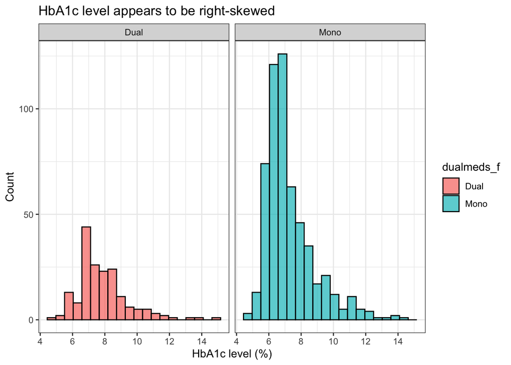

```r
ggplot(study, aes(x = hba1c, fill = dualmeds_f)) +
  geom_histogram(bins = 20, color = "black", alpha = 0.7) +
  facet_wrap(~ dualmeds_f) +
  labs(y = "Count",
       x = "HbA1c level (%)",
       title = "HbA1c level appears to be right-skewed")
```

As we can see in this figure, HbA1c level appears to be right-skewed.

Ignoring covariates, estimate the effect of monotherapy versus dual therapy on the HbA1c levels.

```r
unadjust_outcome <- lm(hba1c ~ dualmeds, data = study)

unadjust_outcome_tidy <- tidy(unadjust_outcome, conf.int = TRUE,
                              conf.level = 0.95) |>
    filter(term == "dualmeds")

unadjust_outcome_tidy |> kable(digits = 3)
```

| term | estimate | std.error | statistic | p.value | conf.low | conf.high |
| --- | --- | --- | --- | --- | --- | --- |
| dualmeds | 0.578 | 0.132 | 4.376 | 0 | 0.319 | 0.837 |

The HbA1c level in the dual therapy group is estimated to be 0.578% (95% CI: 0.319, 0.837) higher than that in the monotherapy group.

# 7 Fitting the PS model

## 7.1 Fitting the Linear Model

I will now fit the propensity score, which predicts treatment status based on available covariates.

```r
psmodel <- glm(dualmeds ~ age + female + race + bmi + sbp +
                 hcare + insurance + alcohol + alcohol_im + sbp_im +
                 insurance_im + bmi_im + hcare_im,
               family = binomial(), data =study_i)

summary(psmodel)
```

```
Call:
glm(formula = dualmeds ~ age + female + race + bmi + sbp + hcare +
    insurance + alcohol + alcohol_im + sbp_im + insurance_im +
    bmi_im + hcare_im, family = binomial(), data = study_i)

Coefficients:
                                Estimate Std. Error z value Pr(>|z|)
(Intercept)                    -4.787996   1.104758  -4.334 1.46e-05 ***
age                             0.030514   0.010741   2.841  0.00450 **
female                         -0.273226   0.198471  -1.377  0.16862
raceBlack                      -0.125378   0.260818  -0.481  0.63072
raceOther                       0.465599   0.227796   2.044  0.04096 *
bmi                             0.014912   0.013269   1.124  0.26111
sbp                             0.005707   0.004575   1.248  0.21221
hcareSometimes                 -0.219129   0.338161  -0.648  0.51698
hcareOften                     -0.338418   0.316748  -1.068  0.28533
insuranceMedicare              -0.141570   0.218461  -0.648  0.51696
insuranceMedicaid               0.392940   0.353352   1.112  0.26612
insuranceUninsured              0.629090   0.295366   2.130  0.03318 *
alcoholLess than once a month   0.686540   0.239904   2.862  0.00421 **
alcohol1 to 4 times a month     0.678976   0.259834   2.613  0.00897 **
alcohol2 to 4 times a week      1.317359   0.315990   4.169 3.06e-05 ***
alcoholEveryday                 1.161230   0.430790   2.696  0.00703 **
alcohol_im                     -0.133578   0.268964  -0.497  0.61944
sbp_im                          0.516700   0.300309   1.721  0.08533 .
insurance_im                    0.258827   0.324867   0.797  0.42562
bmi_im                         -0.451525   0.730550  -0.618  0.53653
hcare_im                      -11.522870 535.411269  -0.022  0.98283
---
Signif. codes:  0 '***' 0.001 '**' 0.01 '*' 0.05 '.' 0.1 ' ' 1

(Dispersion parameter for binomial family taken to be 1)

    Null deviance: 813.12  on 737  degrees of freedom
Residual deviance: 762.51  on 717  degrees of freedom
AIC: 804.51

Number of Fisher Scoring iterations: 12
```

Store the raw and linear propensity scores below.

```r
study_i$ps <- psmodel$fitted
study_i$linps <- psmodel$linear.predictors
```

Checking the propensity score value range.

```r
Hmisc::describe(study_i$ps)
```

```
study_i$ps
       n  missing distinct     Info     Mean  pMedian      Gmd      .05
     738        0      738        1   0.2398    0.232   0.1247  0.09129
     .10      .25      .50      .75      .90      .95
 0.11031  0.15542  0.21911  0.31115  0.39357  0.44507

lowest : 1.28331e-06 0.0290695   0.043374    0.0600333   0.0640886
highest: 0.596915    0.600275    0.610384    0.619655    0.710819
```

There is one subject that has a PS value lower than 0.01, I am going to exclude this subject from further analysis to avoid more problems.

```r
study_i2 <- study_i |>
  filter(ps > 0.01)
```

## 7.2 PS Distributions

Here is a numerical description for the PS of two therapy groups.

```r
mosaic::favstats(ps ~ dualmeds_f, data = study_i2) |>
  kable(digits = 3)
```

| dualmeds_f | min | Q1 | median | Q3 | max | mean | sd | n | missing |
| --- | --- | --- | --- | --- | --- | --- | --- | --- | --- |
| Dual | 0.072 | 0.212 | 0.280 | 0.370 | 0.620 | 0.292 | 0.117 | 177 | 0 |
| Mono | 0.029 | 0.145 | 0.204 | 0.287 | 0.711 | 0.224 | 0.105 | 560 | 0 |

We can see there are no propensity scores equal to, or very close to, 0 or 1.

Next, the distribution of the PS stratified by therapy group are visualize.

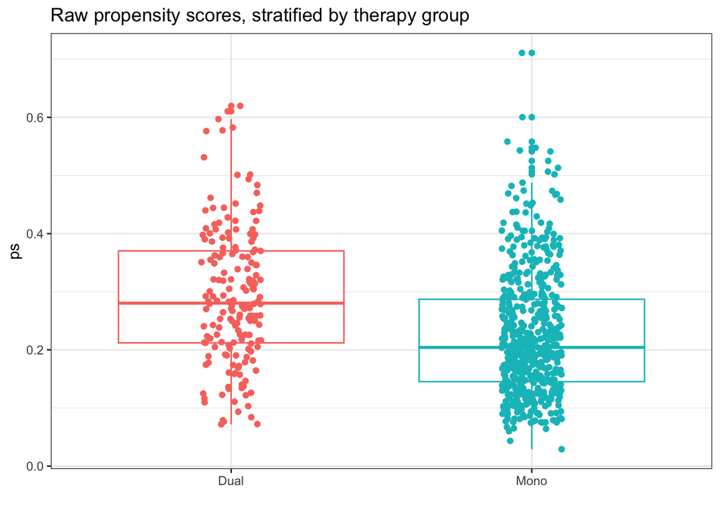

```r
ggplot(study_i2, aes(x = dualmeds_f, y = ps, color = dualmeds_f)) +
  geom_boxplot() +
  geom_jitter(width = 0.1) +
  guides(color = "none") +
  labs(x = "",
     title = "Raw propensity scores, stratified by therapy group")
```

The raw propensity scores are generally lower in the monotherapy group compared to the dual therapy group.

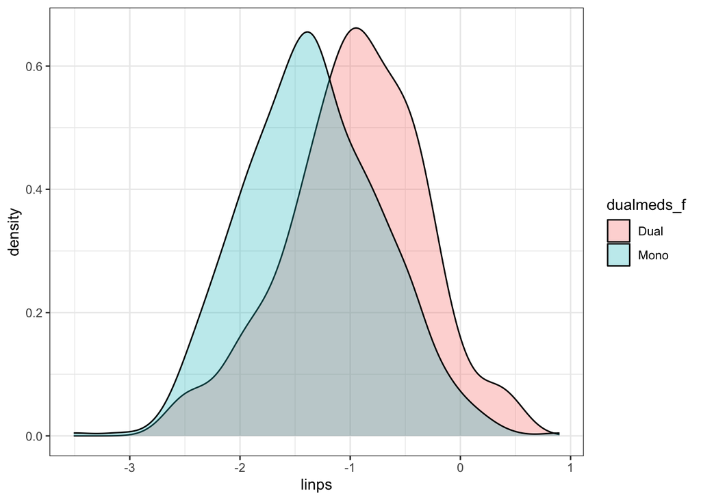

```r
ggplot(study_i2, aes(x = linps, fill = dualmeds_f)) +
  geom_density(alpha = 0.3)
```

There is a fair amount of overlap across the two therapy groups, suggesting that propensity score matching would be helpful in reducing imbalance between the groups.

## 7.3 Rubin’s Rules

### 7.3.1 Rubin’s Rules 1

The absolute value of the standardized difference of the linear propensity score, comparing the dual therapy group to the monotherapy group, should be close to 0, ideally below 10%, and in any case less than 50%.

```r
rubin1.unadj <- with(study_i2,
     abs(100*(mean(linps[dualmeds==1])-mean(linps[dualmeds==0]))/sd(linps)))
rubin1.unadj
```

```
[1] 60.12348
```

Rubin’s Rule 1 is not satisfied.

### 7.3.2 Rubin’s Rules 2

The ratio of the variance of the linear propensity score in the dual therapy group to that in the monotherapy group should be close to 1, ideally falling between 4/5 and 5/4.

```r
rubin2.unadj <-with(study_i2,
                    var(linps[dualmeds==1])/var(linps[dualmeds==0]))
rubin2.unadj
```

```
[1] 0.9894211
```

Rubin’s Rule 2 is satisfied.

# 8 1:1 Matching Approach

## 8.1 The 1:1 Greedy Matching

To address covariate imbalance, 1:1 greedy matching on the linear propensity score will be performed without replacement, with ties broken at random.

```r
X <- study_i2$linps
Tr <- as.logical(study_i2$dualmeds)
match1 <- Match(Tr=Tr, X=X, M = 1, replace=FALSE, ties=FALSE)
summary(match1)
```

```
Estimate...  0
SE.........  0
T-stat.....  NaN
p.val......  NA

Original number of observations..............  737
Original number of treated obs...............  177
Matched number of observations...............  177
Matched number of observations  (unweighted).  177
```

There were 177 subjects in the dual therapy group. After matching, 177 matched pairs were obtained.

```r
set.seed(500)
mb1 <- MatchBalance(dualmeds ~ age + female + race + bmi + sbp +
                      hcare + insurance + alcohol + ps + linps,
                    data=study_i2, match.out = match1, nboots=500)
```

```
***** (V1) age *****
                       Before Matching       After Matching
mean treatment........     64.243            64.243
mean control..........     62.552            63.972
std mean diff.........     16.584            2.6593

mean raw eQQ diff.....     2.1921            1.1864
med  raw eQQ diff.....          2                 1
max  raw eQQ diff.....         11                 4

mean eCDF diff........   0.039388          0.025301
med  eCDF diff........   0.027119          0.025424
max  eCDF diff........    0.12193          0.062147

var ratio (Tr/Co).....    0.74462           0.84967
T-test p-value........   0.065389           0.79464
KS Bootstrap p-value..      0.026             0.756
KS Naive p-value......   0.036663           0.88394
KS Statistic..........    0.12193          0.062147


***** (V2) female *****
                       Before Matching       After Matching
mean treatment........    0.38983           0.38983
mean control..........    0.48393           0.40113
std mean diff.........    -19.239           -2.3103

mean raw eQQ diff.....   0.096045          0.011299
med  raw eQQ diff.....          0                 0
max  raw eQQ diff.....          1                 1

mean eCDF diff........   0.047049         0.0056497
med  eCDF diff........   0.047049         0.0056497
max  eCDF diff........   0.094098          0.011299

var ratio (Tr/Co).....    0.95614           0.99017
T-test p-value........   0.027233           0.82749


***** (V3) raceBlack *****
```

[output cut: 271 more lines]

```
med  eCDF diff........    0.19018         0.0056497
max  eCDF diff........     0.3131          0.028249

var ratio (Tr/Co).....    0.98942            1.0452
T-test p-value........ 4.1165e-12          0.045658
KS Bootstrap p-value.. < 2.22e-16                 1
KS Naive p-value...... 7.0724e-12                 1
KS Statistic..........     0.3131          0.028249


Before Matching Minimum p.value: < 2.22e-16
Variable Name(s): ps linps  Number(s): 16 17

After Matching Minimum p.value: 0.036373
Variable Name(s): ps  Number(s): 16
```

Then, the standardized differences are extracted.

```r
covnames <- c("age", "female", "race", "bmi", "sbp", "hcare", "insurance", "alcohol", "ps", "linps")

pre.szd <- NULL; post.szd <- NULL
for(i in 1:length(covnames)) {
pre.szd[i] <- mb1$BeforeMatching[[i]]$sdiff.pooled
post.szd[i] <- mb1$AfterMatching[[i]]$sdiff.pooled
}

match_szd <- data.frame(covnames, pre.szd, post.szd)
print(match_szd, digits=3)
```

```
    covnames pre.szd post.szd
1        age   15.32     2.66
2     female  -19.02    -2.31
3       race  -14.26     0.00
4        bmi   18.17    -6.76
5        sbp   -5.32    -5.04
6      hcare   14.17     2.97
7  insurance    4.56    -3.71
8    alcohol  -11.30     3.45
9         ps   -4.36     1.23
10     linps    4.91     5.89
```

Overall, covariate balance improved substantially after matching. However, some residual imbalance remains (`sbp`), suggesting that the matching procedure did not fully achieve optimal balance.

## 8.2 The Love Plots

### 8.2.1 Standardized Differences

A plot of standardized differences before and after matching is built.

```r
cobalt_tab <- bal.tab(match1, dualmeds ~ age + female + race + bmi + sbp +
          hcare + insurance + alcohol + ps + linps, data=study_i2,
        un = TRUE, stats = c("m","v"))

cobalt_tab
```

```
Balance Measures
                                  Type Diff.Un V.Ratio.Un Diff.Adj V.Ratio.Adj
age                            Contin.  0.1658     0.7446   0.0266      0.8497
female                          Binary -0.0941          .  -0.0113           .
race_White                      Binary -0.0285          .   0.0339           .
race_Black                      Binary -0.0618          .   0.0000           .
race_Other                      Binary  0.0903          .  -0.0339           .
bmi                            Contin. -0.0537     0.9688  -0.0504      0.9118
sbp                            Contin.  0.1450     0.9128   0.0297      0.7968
hcare_Seldom                    Binary  0.0341          .   0.0000           .
hcare_Sometimes                 Binary  0.0206          .  -0.0169           .
hcare_Often                     Binary -0.0547          .   0.0169           .
insurance_Private               Binary -0.0349          .  -0.0395           .
insurance_Medicare              Binary -0.0202          .   0.0056           .
insurance_Medicaid              Binary  0.0136          .   0.0169           .
insurance_Uninsured             Binary  0.0415          .   0.0169           .
alcohol_Never                   Binary -0.1458          .   0.0169           .
alcohol_Less than once a month  Binary  0.0206          .   0.0000           .
alcohol_1 to 4 times a month    Binary  0.0120          .  -0.0339           .
alcohol_2 to 4 times a week     Binary  0.0775          .   0.0169           .
alcohol_Everyday                Binary  0.0357          .   0.0000           .
ps                             Contin.  0.5873     1.2333   0.0133      1.0645
linps                          Contin.  0.6242     0.9894   0.0099      1.0452

Sample sizes
          Control Treated
All           560     177
Matched       177     177
Unmatched     383       0
```

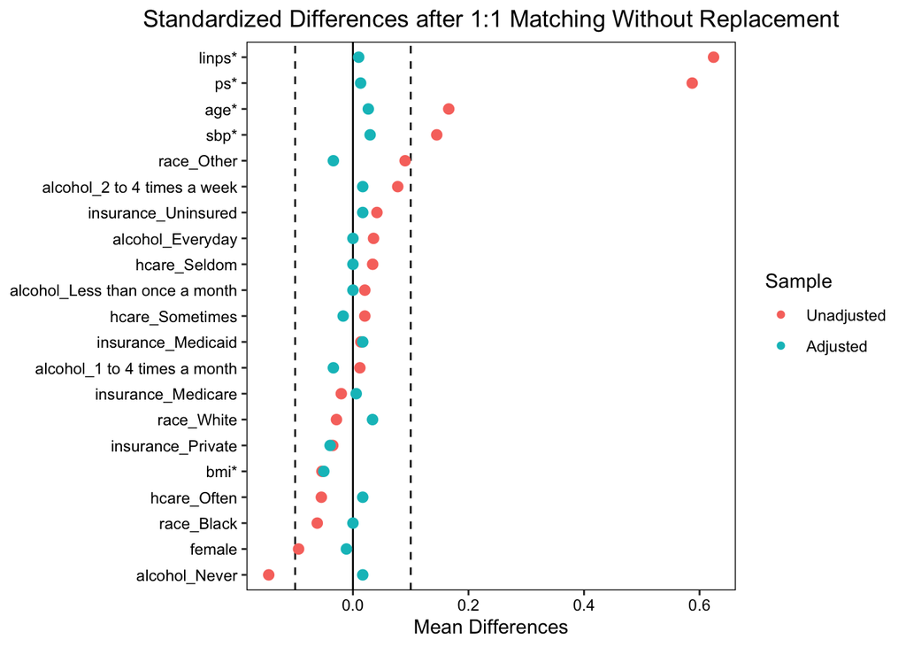

```r
p <- love.plot(cobalt_tab, threshold = .1, size = 3,
               var.order = "unadjusted",
               title = "Standardized Differences after 1:1 Matching Without Replacement",
               stars = "std")

p
```

All covariates fall within an acceptable range of balance after matching.

### 8.2.2 Variance Ratios

A plot of variance ratios before and after matching is built.

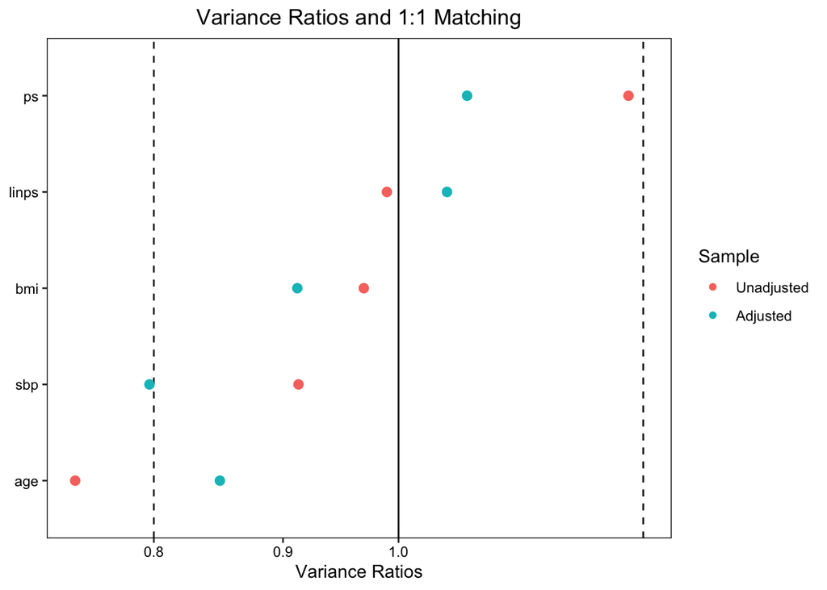

```r
love.plot(cobalt_tab, stat = "v",
               threshold = 1.25, size = 3,
               var.order = "unadjusted",
               title = "Variance Ratios and 1:1 Matching")
```

## 8.3 Matched Data

A data frame including the matched sample is created.

```r
matches <- factor(rep(match1$index.treated, 2))
study_i2.matchedsample <- cbind(matches, study_i2[c(match1$index.control, match1$index.treated),])

study_i2.matchedsample |> count(dualmeds_f)
```

```
  dualmeds_f   n
1       Dual 177
2       Mono 177
```

Create a table that contains both before and after matching along with the standardized difference values.

```r
tab_before <- CreateTableOne(
  vars = var_list,
  strata = "dualmeds_f",
  data = study,
  factorVars = factor_list,
  test = FALSE)

before_df <- print(
  tab_before,
  smd = TRUE,
  printToggle = FALSE,
  noSpaces = TRUE)

# After matching
tab_after <- CreateTableOne(
  vars = var_list,
  strata = "dualmeds_f",
  data = study_i2.matchedsample,
  factorVars = factor_list,
  test = FALSE)

after_df <- print(
  tab_after,
  smd = TRUE,
  printToggle = FALSE,
  noSpaces = TRUE)

colnames(before_df) <- paste0("Before_", colnames(before_df))
colnames(after_df)  <- paste0("After_", colnames(after_df))

table1_combined <- cbind(
  Variable = rownames(before_df),
  before_df,
  after_df)

rownames(table1_combined) <- NULL

table1_combined
```

```
      Variable                    Before_Dual     Before_Mono     Before_SMD
 [1,] "n"                         "177"           "561"           ""
 [2,] "hba1c (mean (SD))"         "7.86 (1.58)"   "7.28 (1.52)"   "0.373"
 [3,] "female_f = male (%)"       "108 (61.0)"    "289 (51.5)"    "0.192"
 [4,] "age (mean (SD))"           "64.24 (10.20)" "62.58 (11.83)" "0.150"
 [5,] "bmi (mean (SD))"           "32.49 (7.29)"  "32.91 (7.46)"  "0.057"
 [6,] "race (%)"                  ""              ""              "0.191"
 [7,] "   White"                  "49 (27.7)"     "172 (30.7)"    ""
 [8,] "   Black"                  "39 (22.0)"     "158 (28.2)"    ""
 [9,] "   Other"                  "89 (50.3)"     "231 (41.2)"    ""
[10,] "hcare (%)"                 ""              ""              "0.139"
[11,] "   Seldom"                 "19 (10.7)"     "41 (7.3)"      ""
[12,] "   Sometimes"              "52 (29.4)"     "153 (27.3)"    ""
[13,] "   Often"                  "106 (59.9)"    "366 (65.4)"    ""
[14,] "insurance (%)"             ""              ""              "0.143"
```

[output cut: 35 more lines]

And the table is saved as “csv” file for future use.

```r
write.csv(table1_combined, "Table1_before_after_matching2.csv", row.names = FALSE)
```

## 8.4 Reassessing Rubin’s Rules

### 8.4.1 Rubin’s Rule 1

```r
rubin1.match <- with(study_i2.matchedsample,
abs(100*(mean(linps[dualmeds==1])-mean(linps[dualmeds==0]))/sd(linps)))
rubin1.match
```

```
[1] 1.004745
```

Rubin’s Rule 1 is satisfied.

### 8.4.2 Rubin’s Rule 2

```r
rubin2.match <- with(study_i2.matchedsample, var(linps[dualmeds==1])/var(linps[dualmeds==0]))
rubin2.match
```

```
[1] 1.045182
```

Rubin’s Rule 2 is satisfied as well.

## 8.5 Treatment Effect (mixed-effects model)

A mixed-effects model will be used to estimate the treatment effect of the two therapy groups on HbA1c levels.

```r
study_i2.matchedsample$matches.f <- as.factor(study_i2.matchedsample$matches)

matched_mixedmodel.out1 <- lmer(hba1c ~ dualmeds + (1 | matches.f), data=study_i2.matchedsample)
```

```r
res_matched_1 <- broom.mixed::tidy(matched_mixedmodel.out1,
                      conf.int = T, conf.level = 0.95) |>
    filter(term == "dualmeds")

res_matched_1 |> kable(digits = 3)
```

| effect | group | term | estimate | std.error | statistic | conf.low | conf.high |
| --- | --- | --- | --- | --- | --- | --- | --- |
| fixed | NA | dualmeds | 0.518 | 0.166 | 3.118 | 0.192 | 0.843 |

Subjects who received dual therapy had an estimated HbA1c level that was 0.518% (95% CI: 0.192 to 0.843) higher than those who received monotherapy, suggesting a meaningful difference.

## 8.6 Sensitivity Analysis

```r
X <- study_i2$linps ## matching on the linear propensity score
Tr <- as.logical(study_i2$dualmeds)
Y <- study_i2$hba1c
match1 <- Match(Tr=Tr, X=X, Y = Y, M = 1, replace=FALSE, ties=FALSE)
summary(match1)
```

```
Estimate...  0.56723
SE.........  0.15465
T-stat.....  3.6679
p.val......  0.00024457

Original number of observations..............  737
Original number of treated obs...............  177
Matched number of observations...............  177
Matched number of observations  (unweighted).  177
```

```r
Rc <- match1$mdata$Y[match1$mdata$Tr==0]
Rt <- match1$mdata$Y[match1$mdata$Tr==1]


psens(Rt, Rc, Gamma = 1.6, GammaInc = 0.1)
```

```
 Rosenbaum Sensitivity Test for Wilcoxon Signed Rank P-Value

Unconfounded estimate ....  1e-04

 Gamma Lower bound Upper bound
   1.0       1e-04      0.0001
   1.1       0e+00      0.0004
   1.2       0e+00      0.0021
   1.3       0e+00      0.0076
   1.4       0e+00      0.0215
   1.5       0e+00      0.0491
   1.6       0e+00      0.0953

 Note: Gamma is Odds of Differential Assignment To
 Treatment Due to Unobserved Factors
```

The sensitivity analysis shows that the result remains significant up to $\Gamma$ = 1.5 but becomes non-significant at $\Gamma$ = 1.6. This suggests that the conclusion is moderately sensitive to unmeasured confounding.

# 9 ATT Weighting Approach

For this analysis, an ATT (average treatment effect on the treated) approach is used, with the linear propensity score included as an adjustment variable in the final weighted outcome model.

## 9.1 ATT weights

ATT weights are calculated by assigning a weight of 1 to treated subjects and a weight of $\frac{ps}{1 - ps}$ to control subjects.

```r
study_i2$wts1 <- ifelse(study_i2$dualmeds==1, 1,
                        study_i2$ps/(1-study_i2$ps))
```

The resulting ATT weights are plotted.

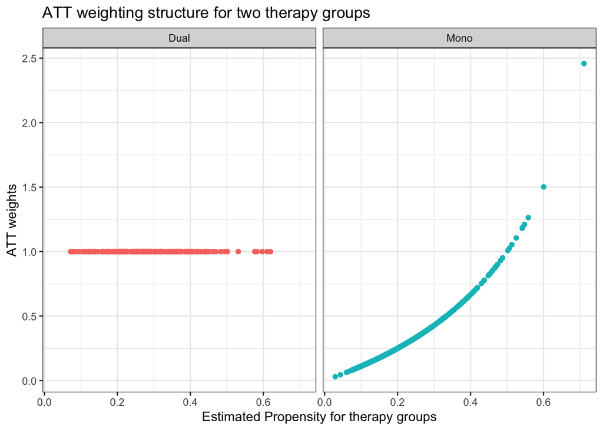

```r
ggplot(study_i2, aes(x = ps, y = wts1, color = dualmeds_f)) +
    geom_point() +
    guides(color = "none") +
    facet_wrap(~ dualmeds_f) +
    labs(x = "Estimated Propensity for therapy groups",
         y = "ATT weights",
         title = "ATT weighting structure for two therapy groups")
```

## 9.2 Assessing Balance after Weighting

```r
study_df <- base::data.frame(study_i2)

bal.wts1 <- dx.wts(x=study_df$wts1, data=study_df, vars=covnames,
                   treat.var="dualmeds", estimand="ATT")
bal.wts1
```

```
  type n.treat n.ctrl ess.treat ess.ctrl     max.es    mean.es     max.ks
1  unw     177    560       177 560.0000 0.62423307 0.16541931 0.31309524
2          177    560       177 369.4139 0.03461018 0.01355599 0.07602119
     mean.ks iter
1 0.08156203   NA
2 0.01951870   NA
```

```r
bal.table(bal.wts1)
```

```
$unw
                                 tx.mn  tx.sd   ct.mn  ct.sd std.eff.sz   stat
age                             64.243 10.198  62.552 11.818      0.166  1.852
female                           0.390  0.489   0.484  0.500     -0.192 -2.223
race:White                       0.277  0.447   0.305  0.461     -0.064  2.404
race:Black                       0.220  0.414   0.282  0.450     -0.149     NA
race:Other                       0.503  0.500   0.413  0.492      0.181     NA
bmi                             32.538  7.306  32.931  7.422     -0.054 -0.621
sbp                            133.051 20.344 130.100 21.293      0.145  1.666
hcare:Seldom                     0.107  0.310   0.073  0.260      0.110  1.377
hcare:Sometimes                  0.294  0.455   0.273  0.446      0.045     NA
hcare:Often                      0.599  0.490   0.654  0.476     -0.112     NA
insurance:Private                0.463  0.499   0.498  0.500     -0.070  0.943
insurance:Medicare               0.299  0.458   0.320  0.466     -0.044     NA
insurance:Medicaid               0.090  0.287   0.077  0.266      0.047     NA
insurance:Uninsured              0.147  0.354   0.105  0.307      0.117     NA
alcohol:Never                    0.254  0.435   0.400  0.490     -0.335  5.232
alcohol:Less than once a month   0.294  0.455   0.273  0.446      0.045     NA
alcohol:1 to 4 times a month     0.232  0.422   0.220  0.414      0.028     NA
alcohol:2 to 4 times a week      0.153  0.360   0.075  0.263      0.216     NA
alcohol:Everyday                 0.068  0.251   0.032  0.176      0.142     NA
ps                               0.292  0.117   0.224  0.105      0.587  6.983
linps                           -0.959  0.616  -1.344  0.619      0.624  7.242
                                   p    ks ks.pval
age                            0.064 0.122   0.034
female                         0.027 0.094   0.173
race:White                     0.091 0.029   0.091
race:Black                        NA 0.062   0.091
race:Other                        NA 0.090   0.091
bmi                            0.535 0.082   0.306
sbp                            0.096 0.097   0.152
hcare:Seldom                   0.253 0.034   0.253
hcare:Sometimes                   NA 0.021   0.253
hcare:Often                       NA 0.055   0.253
insurance:Private              0.419 0.035   0.419
insurance:Medicare                NA 0.020   0.419
insurance:Medicaid                NA 0.014   0.419
insurance:Uninsured               NA 0.042   0.419
alcohol:Never                  0.000 0.146   0.000
alcohol:Less than once a month    NA 0.021   0.000
```

[output cut: 36 more lines]

```
sbp                            0.922 0.063   0.698
hcare:Seldom                   0.967 0.007   0.967
hcare:Sometimes                   NA 0.006   0.967
hcare:Often                       NA 0.001   0.967
insurance:Private              0.999 0.003   0.999
insurance:Medicare                NA 0.005   0.999
insurance:Medicaid                NA 0.002   0.999
insurance:Uninsured               NA 0.000   0.999
alcohol:Never                  0.999 0.003   0.999
alcohol:Less than once a month    NA 0.000   0.999
alcohol:1 to 4 times a month      NA 0.006   0.999
alcohol:2 to 4 times a week       NA 0.010   0.999
alcohol:Everyday                  NA 0.002   0.999
ps                             0.768 0.062   0.719
linps                          0.806 0.062   0.719
```

To construct a standardized difference plot, the standardized effect sizes are first extracted and multiplied by 100 to obtain percentage standardized differences. The results are then sorted by the pre-weighting standardized differences to produce the required table.

```r
szd.weight1 <- data.frame(
  names = rownames(bal.table(bal.wts1)[[2]]),
  prew.szd = 100 * bal.table(bal.wts1)[[1]]$std.eff.sz,
  postw.szd = 100 * bal.table(bal.wts1)[[2]]$std.eff.sz)

szd.weights <- szd.weight1[with(szd.weight1, order(prew.szd)), ]
szd.weights
```

```
                            names prew.szd postw.szd
15                  alcohol:Never    -33.5       0.7
2                          female    -19.2       0.9
4                      race:Black    -14.9      -0.4
10                    hcare:Often    -11.2       0.2
11              insurance:Private     -7.0      -0.5
3                      race:White     -6.4       3.5
6                             bmi     -5.4      -1.1
12             insurance:Medicare     -4.4       1.2
17   alcohol:1 to 4 times a month      2.8       1.4
9                 hcare:Sometimes      4.5       1.3
16 alcohol:Less than once a month      4.5       0.0
13             insurance:Medicaid      4.7      -0.8
8                    hcare:Seldom     11.0      -2.3
14            insurance:Uninsured     11.7      -0.1
19               alcohol:Everyday     14.2       0.7
7                             sbp     14.5      -0.9
1                             age     16.6       1.3
5                      race:Other     18.1      -2.8
18    alcohol:2 to 4 times a week     21.6      -2.9
20                             ps     58.7      -3.2
21                          linps     62.4      -2.5
```

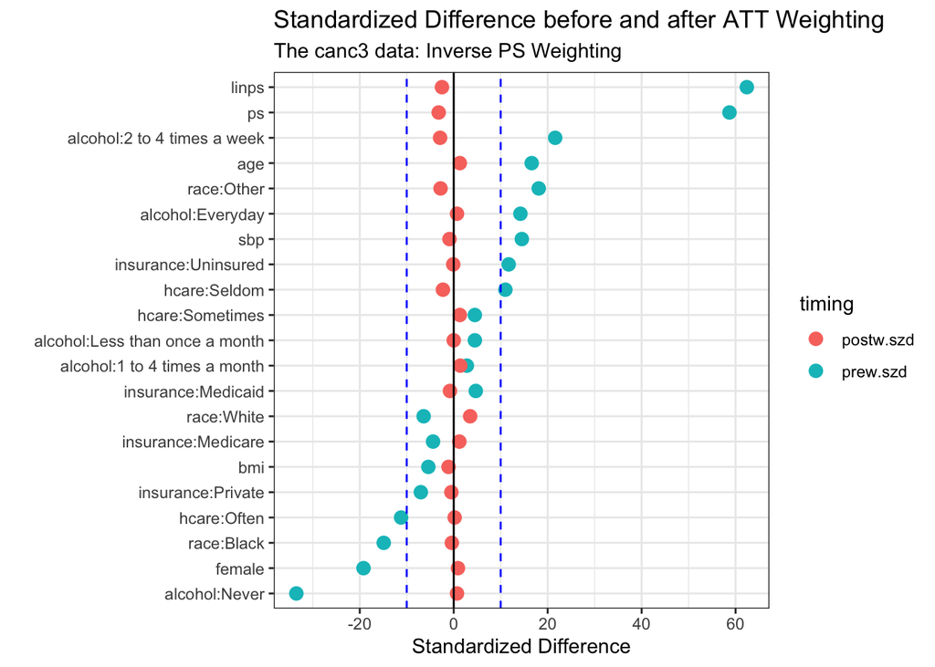

```r
szd.weight1_plot <- gather(data = szd.weights, key = timing, value = szd, 2:3)

ggplot(szd.weight1_plot, aes(x = szd, y = reorder(names, szd),
                             color = timing)) +
    geom_point(size = 3) +
    geom_vline(xintercept = 0) +
    geom_vline(xintercept = c(-10,10), linetype = "dashed", col = "blue") +
    theme_bw() +
    labs(x = "Standardized Difference", y = "",
         title = "Standardized Difference before and after ATT Weighting",
         subtitle = "The canc3 data: Inverse PS Weighting")
```

All covariates achieved much substantially improved balance after ATT weighting.

## 9.3 Evaluating Rubin’s Rules

### 9.3.1 Rubin’s Rule 1

From the `bal.table` output above, the `std.eff.sz` for `linps` after the weighting is -0.025, so that is a standardized difference of 100 x -0.025 = -2.5%. The Rubin’s Rule 1 is satisfied.

### 9.3.2 Rubin’s Rule 2

Numbers from `linps` row in part [2] of balance table above: $\frac{0.616^2}{0.646^2}$ = 0.9092774. Passes Rule 2.

## 9.4 Double Robust Approach

```r
wt1.design <- svydesign(ids=~1, weights=~wts1, data=study_i2)

dr.out1.wt1 <- svyglm(hba1c ~ dualmeds + linps, design=wt1.design)

dr_att_out1 <- tidy(dr.out1.wt1, conf.int = TRUE) |> filter(term == "dualmeds")

dr_att_out1 |> kable(digits = 3)
```

| term | estimate | std.error | statistic | p.value | conf.low | conf.high |
| --- | --- | --- | --- | --- | --- | --- |
| dualmeds | 0.598 | 0.139 | 4.304 | 0 | 0.325 | 0.871 |

Subjects who received dual therapy had an estimated HbA1c level that was 0.598% (95% CI: 0.325 to 0.871) points higher than those who received monotherapy, suggesting a meaningful difference.

# 10 Results

## 10.1 Treatment Effect Estimates

Finally, I compare the estimated HbA1c levels between monotherapy and dual therapy obtained from the unadjusted analysis, 1:1 greedy matching, and ATT weighting.

[output not shown]

The graphical display of the results is shown below.

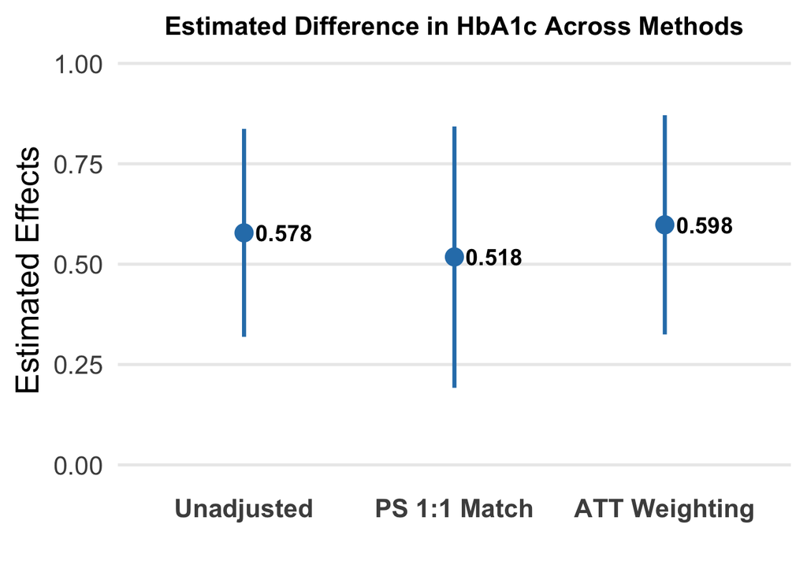

```r
results <- tibble(
  Analysis = c("Unadjusted", "PS 1:1 Match", "ATT Weighting"),
  Estimate = c(0.578, 0.518, 0.598),
  conf.low = c(0.319, 0.192, 0.325),
  conf.high = c(0.837, 0.843, 0.871)) |>
  mutate(
    Analysis = factor(Analysis, levels = Analysis),
    label = sprintf("%.3f", Estimate))

ggplot(results, aes(x = Analysis, y = Estimate)) +
  geom_pointrange(aes(ymin = conf.low, ymax = conf.high),
                  size = 0.8, linewidth = 1.2,
                  color = "#2C7FB8") +
  geom_text(aes(label = label),
            hjust = -0.2,
            size = 5,
            fontface = "bold") +
  labs(title = "Estimated Difference in HbA1c Across Methods",
       x = "", y = "Estimated Effects") +
  theme_minimal(base_size = 20) +
  theme(
    plot.title = element_text(face = "bold", size = 16, hjust = 0.5),
    axis.text.x = element_text(face = "bold"),
    panel.grid.major.x = element_blank(),
    panel.grid.minor = element_blank()) +
  coord_cartesian(ylim = c(0, max(results$conf.high) + 0.1))
```

The results consistently show that, compared with monotherapy, dual therapy is associated with higher HbA1c levels among patients with T2DM or hyperglycemia.

In the unadjusted analysis, patients receiving dual therapy had HbA1c levels that were 0.578% higher than those receiving monotherapy (95% CI: 0.319, 0.837). This association remained consistent after adjustment using both 1:1 greedy matching and ATT weighting, with estimated differences of 0.518 (95% CI: 0.192, 0.843) and 0.598 (95% CI: 0.325, 0.871), respectively.

## 10.2 Quality of Balance

The balance (standardized differences and variance ratios) across all the covariates are summarized below.

[output not shown]

All analytic approaches achieved improved covariate balance after adjustment.

# 11 Conclusion

In terms of covariate balance, the unadjusted data exhibited substantial imbalance, with standardized differences ranging from −19 to 18.2. This imbalance was reduced after matching (−6.8 to 5.9) and also minimized by ATT weighting (−3.2 to 3.5). Overall, as covariate balance improved, the estimated treatment effects became more reliable, suggesting that proper adjustment for confounding is essential in estimating the association between treatment and HbA1c levels.

The estimated differences in HbA1c were very similar across all three analytic approaches, indicating that adjustment for measured confounding did not substantially alter the results. In particular, the ATT weighting analysis produced an estimate that was nearly identical to the unadjusted result, suggesting that weighting did not meaningfully change the composition of the analytic population. 1:1 greedy propensity score matching yielded a slightly smaller estimated difference. This may reflect the fact that matching restricts the analysis to a more comparable subset of patients by discarding unmatched individuals, whereas weighting retains a broader population and targets the average treatment effect among the treated.

Additionally, sensitivity analysis indicated that the matched results were somewhat sensitive to unmeasured confounding, suggesting that the observed association should be interpreted with caution.

One possible explanation for the higher HbA1c levels observed among subjects receiving dual therapy is confounding by indication. Patients are typically prescribed combination therapy when their glycemic control is inadequate under monotherapy or when their disease is more severe. Individuals receiving both metformin and sulfonylureas may already have higher baseline HbA1c levels or more advanced diabetes compared to those receiving a single agent. Although propensity score methods were used to adjust for observed covariates, residual confounding may still exist due to unmeasured factors such as duration of diabetes, medication adherence, or lifestyle behaviors that are not fully captured in the data.

# 12 AI Usage

AI tools were used to support the development of code in this file and to assist in refining the wording of the written content.